# Improving the Appearance of your Notebook

These are just some specific customization and improvements you can incorporate in your `.Rmd` files. More information may be found at https://bookdown.org/yihui/rmarkdown/html-document.html

```r
library(tidyverse)
```

# 1 Buttons/Tabs for Sub-sections

Save space in your document using buttons or tabs for sub-sections. Below is the way this Section was defined

```
# Buttons/Tabs for Sub-sections {.tabset .tabset-fade .tabset-pills}
```

## 1.1 First Section

A first section

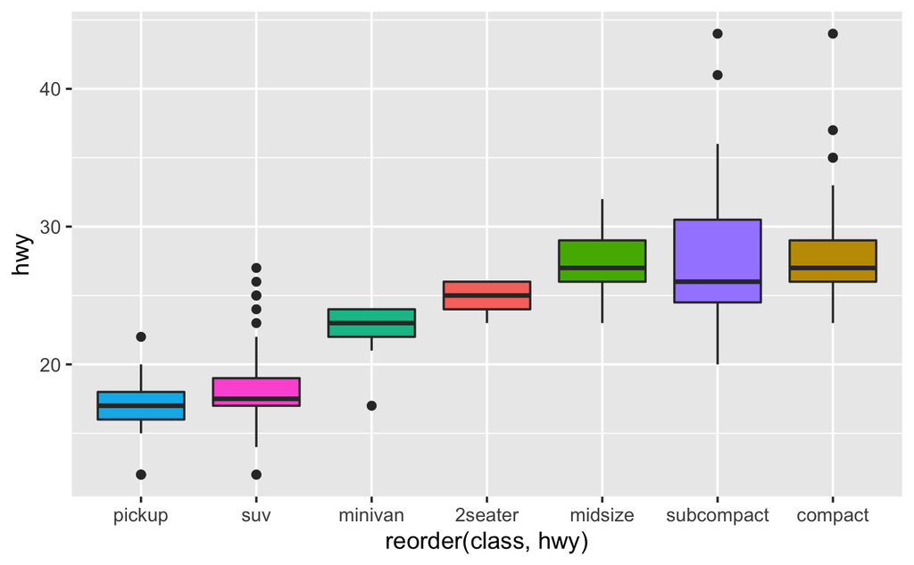

```r
ggplot(data = mpg,
       aes(x=reorder(class, hwy), y=hwy, fill=class)) +
  geom_boxplot() +
  theme(legend.position="none")
```

## 1.2 Second Section

Content of sub-chapter #2

$$x_{k+1} = x_k - \frac{f(x_k)}{f^\prime(x_k)}$$

## 1.3 Third Section

Content of sub-chapter #3

```r
set.seed(217)
sample_n(tbl = mpg, size = 4)
```

| manufacturer | model | displ | year | cyl | trans | drv | cty | hwy | fl | class |
| --- | --- | --- | --- | --- | --- | --- | --- | --- | --- | --- |
| subaru | forester awd | 2.5 | 1999 | 4 | auto(l4) | 4 | 18 | 24 | r | suv |
| dodge | caravan 2wd | 3.8 | 1999 | 6 | auto(l4) | f | 15 | 22 | r | minivan |
| volkswagen | passat | 3.6 | 2008 | 6 | auto(s6) | f | 17 | 26 | p | midsize |
| hyundai | tiburon | 2.7 | 2008 | 6 | manual(m5) | f | 17 | 24 | r | subcompact |

# 2 Automatic Numbering

You can modify the YAML in your `.Rmd` to automatically the sections and sub-sections in your document. This example already does that. For example, your header would look like:

```
---
title: "Your title"
output:
  html_document:
    number_sections: TRUE
---
```

# 3 Highlight a piece of text

You can apply some `css` to a specific part of your document. For example, it may be useful to highlight conclusions at the end of your document.

The code below generates a list with highlighted items:

```
<style>
div.blue { background-color:#E6E6FA; border-radius: 5px; padding: 20px;}
</style>
<div class = "blue">
- We love data
- This was a good class
</div>
```

- We love data
- This was a good class

# 4 Table of Contents

This example has a table of contents *floating* on the side. For this, the YAML looks like:

```
title: "Habits"
output:
  html_notebook:
    toc: true
    toc_float: true
    toc_depth: 2
```

# 5 Skip a line

This is done using the `<br>` command. This `.Rmd` code:

```
Rei Sanchez-Arias
<br><br><br><br>
Data Science and Business Analytics
```

will produce:

Rei Sanchez-Arias  
Data Science and Business Analytics

# 6 Centering Images

You could use the code below

```
<center>
![Site logo](https://github.com/reisanar/figs/raw/master/icon-192.png)
</center>
```

[figure not shown]

Another approach is to use the `knitr::includegraphics()` function, and determine the options of the chunk of code specifying `fig.align='center'` (should work well for a R Markdown file)

```r
# knitr::include_graphics("https://github.com/reisanar/figs/raw/master/icon-192.png")
```

# 7 Internal Links

You can use internal links in R Markdown using *anchors*. For example, this link will bring you to the previous chapter. To do it:

1 - Put an anchor next to a title. This is how one of the previous section title looks like:

```
# Highlight a piece of text {#highlight}
```

2. Put a link to an anchor:

Check the reasons why we like this course here